# Summary Statistics

Julian McClellan

# Data Cleaning procedures

## Clean Sample

- Initial Size: 2449
- Remove blank email addresses 105
- `period` column created with values `fall12` and `spring13` corresponding to `TRUE` values of `fall12dum` and `spring13dum` respectively.
- Final size: 2344

## Price Beliefs

- Initial Size: 4785
- **Did not** remove unfinished surveys (537 did not finish.)
- `period` column created with values `fall12` and `spring13`.
  - `startyear` and `startmonth` created from original column `startdate`
  - `period=fall12` set if `startyear == 2012` and (`startmonth == 11` or `startmonth == 12`)
  - `period=spring13` set if `startyear == 2013` and `startmonth == 4`
- Final size: 4785

# Summary Statistics Plots for Clean Sample Data

## General Treatment Breakdown

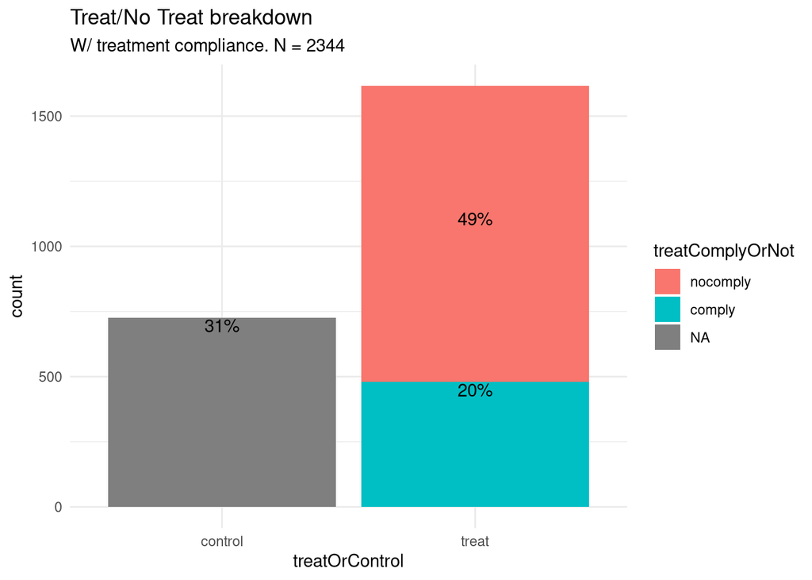

## Treatment Breakdown: Classes

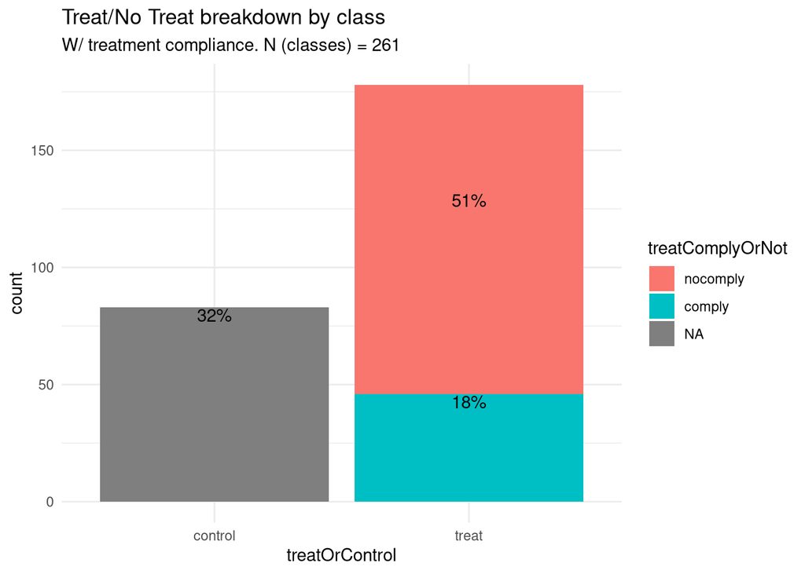

## Treatment Breakdown: Book Price Comparison

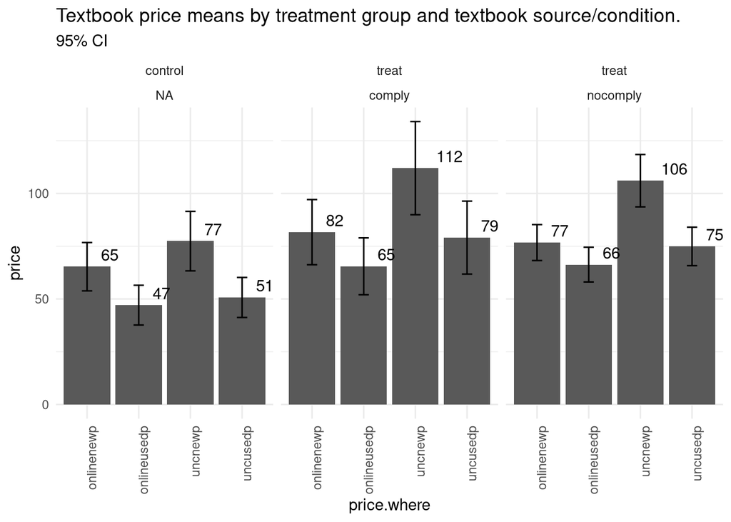

## Treatment Breakdown: Clean Sample Class in Student Major

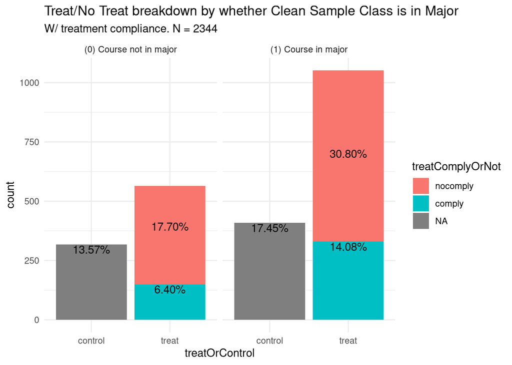

## Treatment Breakdown: Clean Sample Students’ Freshman Status

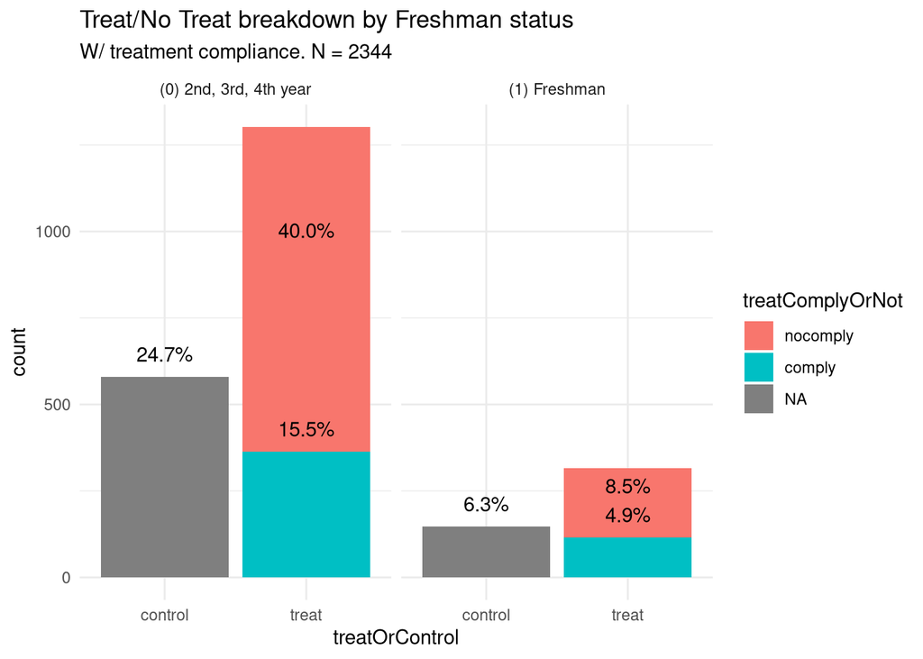

# Summary Statistics Plots for Loose Joined Data

## Overview of Join

The “loose” joined data joins the clean sample and price beliefs tables on `email` and `period`. Period joins are allowed only if the `period` of the clean sample is the same as the price beliefs `period`.

## General Treatment Breakdown

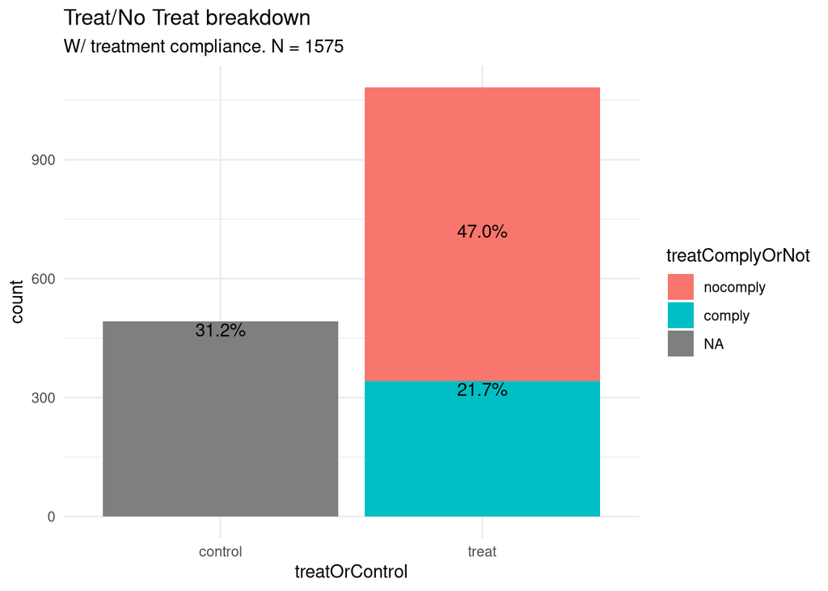

## Treatment Breakdown: Classes

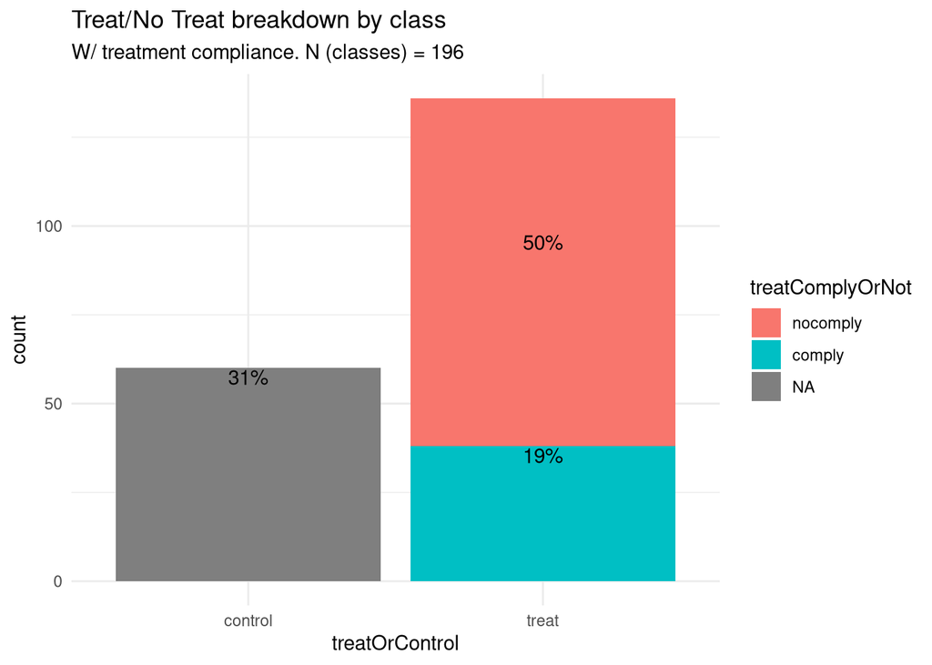

## Treatment Breakdown: Book Price Comparison

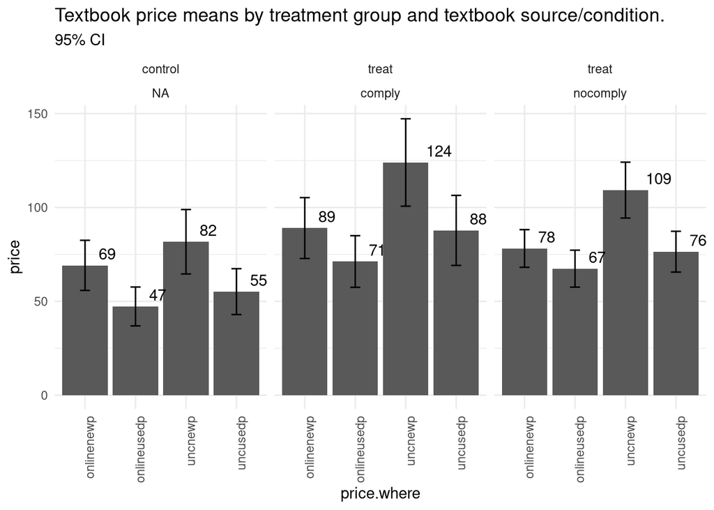

## Treatment Breakdown: Clean Sample Class in Student Major

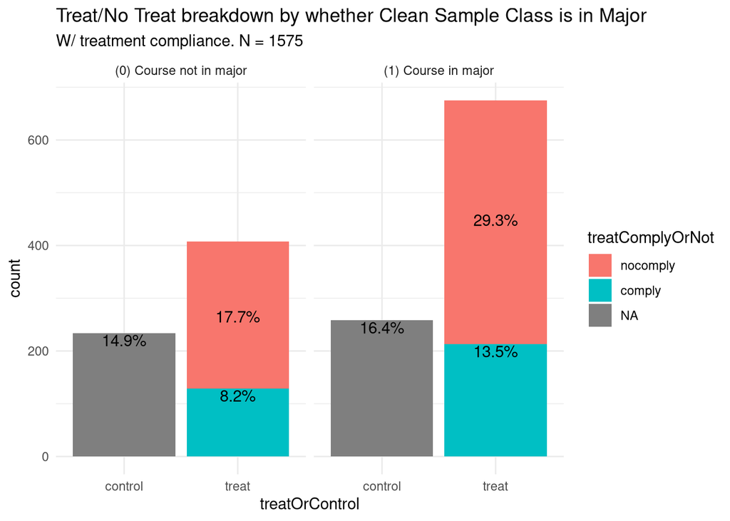

## Treatment Breakdown: Clean Sample Students’ Freshman Status

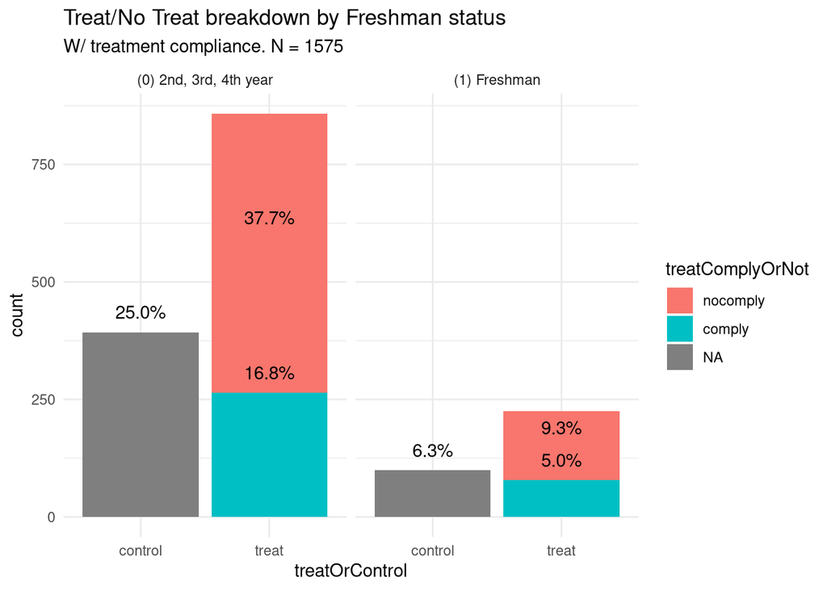

# Summary Statistics Plots for Looser Joined Data

## Overview of Join

The “looser” joined data joins the clean sample and price beliefs tables on `email` and `period`. Period joins are allowed as long as the `period` of the clean sample occurs during the same `period` or earlier than the price beliefs. `period.cs <= period.pb`

## General Treatment Breakdown

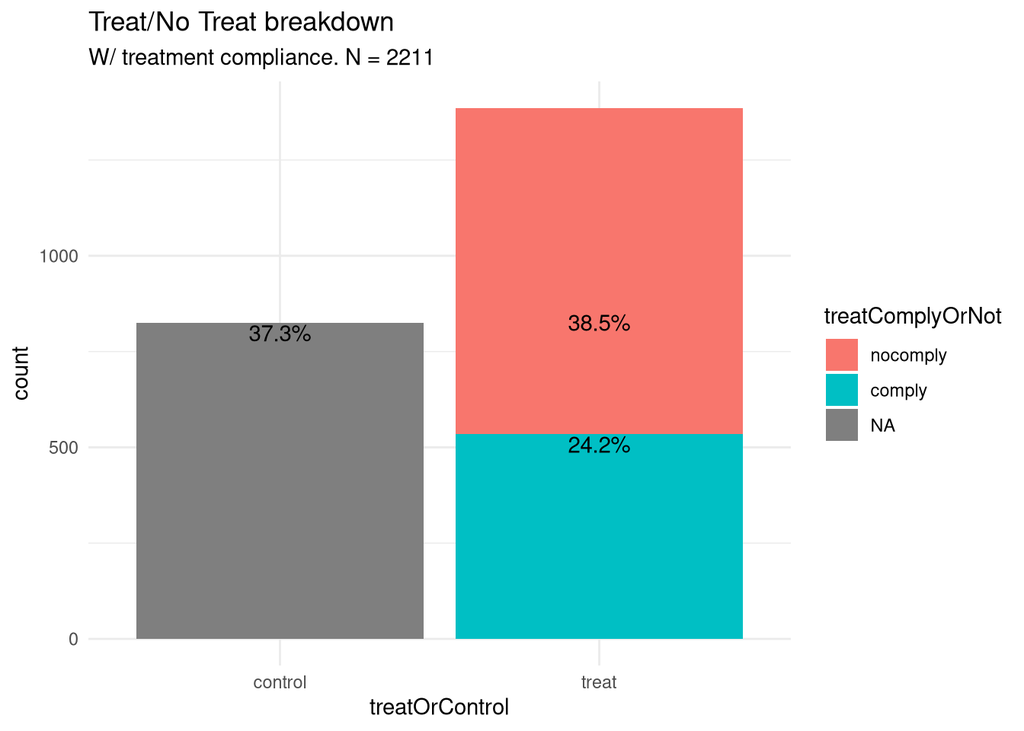

## Treatment Breakdown: Classes

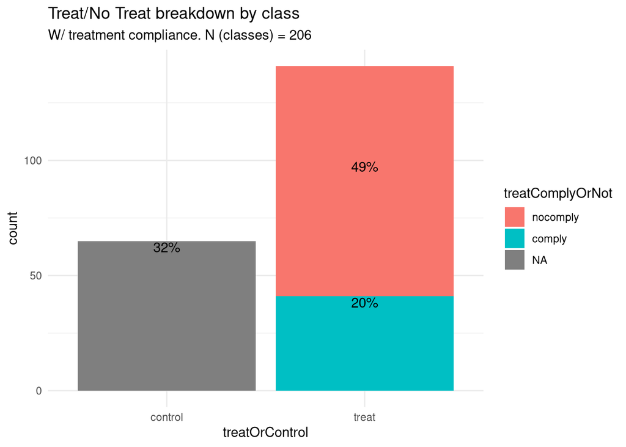

## Treatment Breakdown: Book Price Comparison

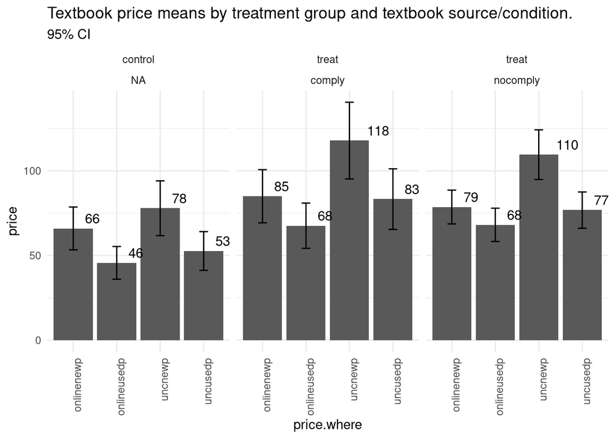

## Treatment Breakdown: Clean Sample Class in Student Major

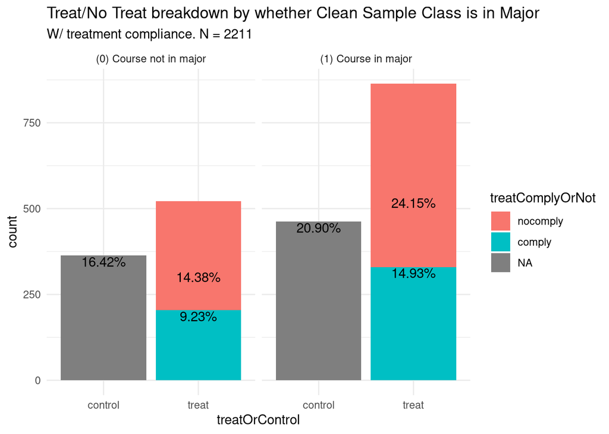

## Treatment Breakdown: Clean Sample Students’ Freshman Status

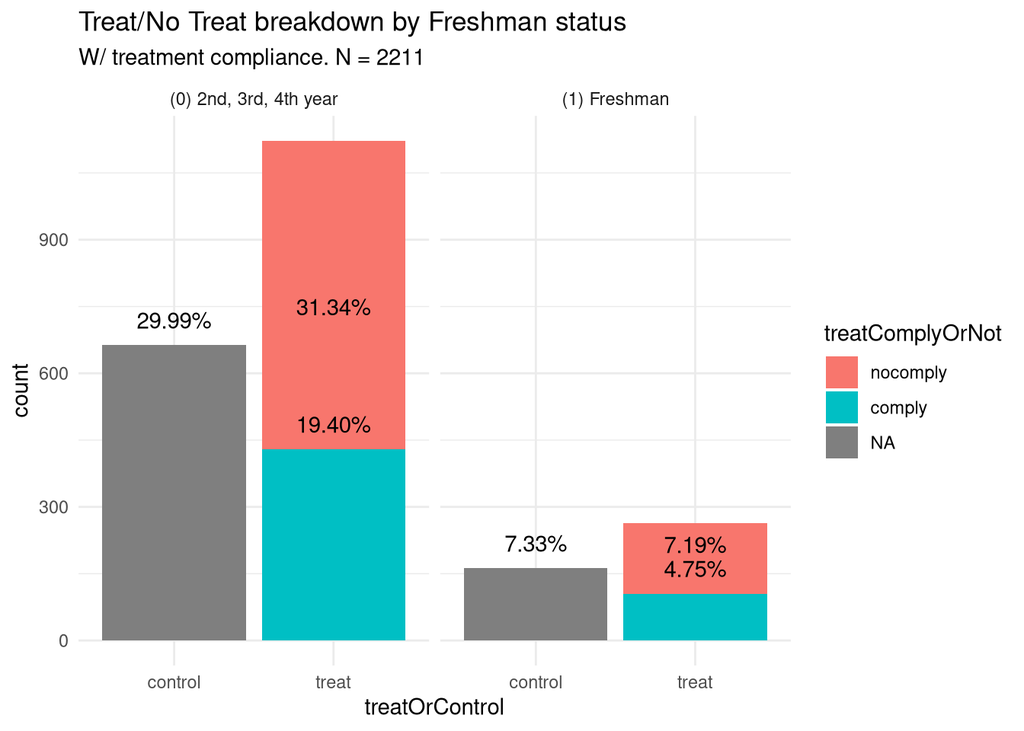